# Yashpreet Kaur (yk8742)

## Individual Assignment #2: ARIMA Lab.

#### Due: Nov. 23 before class time

#### (40 points)

In the following code box we read the CSV file and set up the data as a *tsibble* and then we plot it and subset it to examine it.

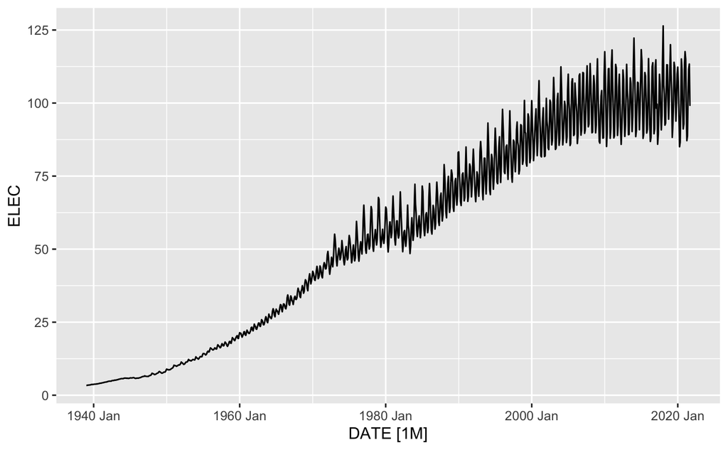

```r
library(fpp3)

D <- read.csv("US Electricity.csv") %>%
  mutate(DATE = yearmonth(DATE)) %>%
  as_tsibble(index = DATE)

D %>% autoplot(ELEC)
```

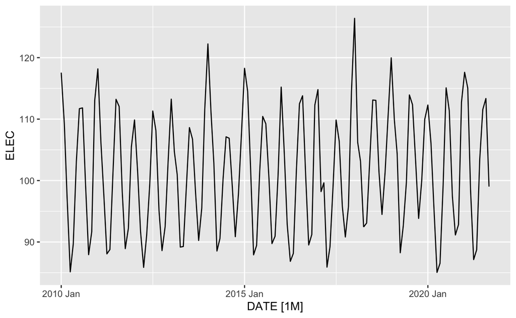

```r
DR <- D %>% filter(DATE >= yearmonth("2010 Jan"))

DR %>% autoplot(ELEC)
```

We are interested in developing a two-year long monthly forecast (24 months) for the national electricity production requirements.

1. Examine the stationarity of the **ELEC** time series in the reduced **DR** data, examine also the corresponding ACF and PACF diagrams and propose three plausible ARIMA models to fit the data.

**We observe from the above trends that data is non-stationary and has seasonality. So, we conduct unitroot_nsdiffs and unitroot_ndiffs tests to find the number of seasonal and normal differences required in order to get stationary trend.**

```r
#checking the number of differences using unit root method
DR %>%
  features(ELEC, unitroot_nsdiffs)
```

| nsdiffs |
| --- |
| 1 |

```r
DR %>%
  features(ELEC, unitroot_ndiffs)
```

| ndiffs |
| --- |
| 0 |

**We observe that unitroot_nsdiffs() returns 1 indicating one seasonal difference is required. Similarly, we also apply the unitroot_ndiffs() function to the data which returns 0. These functions suggest we should do a seasonal difference only.**

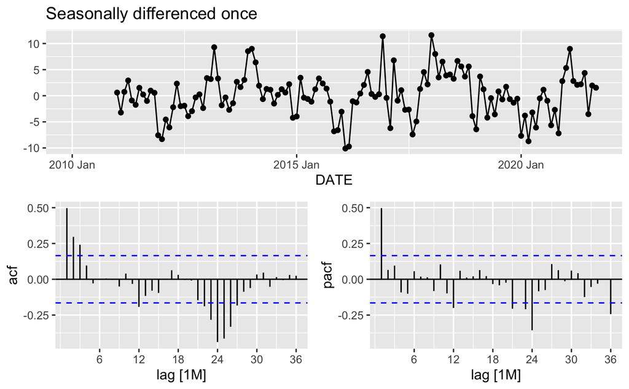

```r
#one seasonal difference taken as suggested by the unit root method

DR %>%
  gg_tsdisplay(difference(ELEC, 12),
               plot_type='partial', lag=36) +
  labs(title="Seasonally differenced once", y="")
```

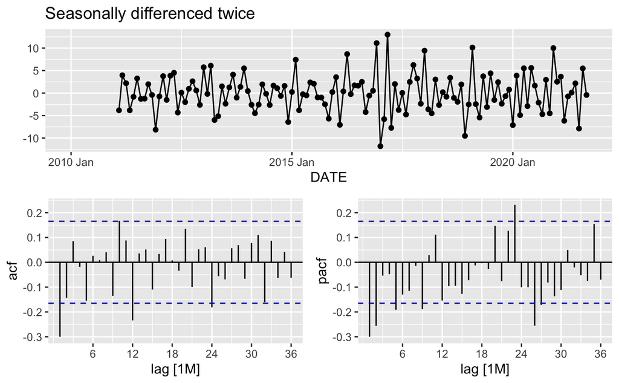

```r
#additional model involving double seasonal difference

DR %>%
  gg_tsdisplay(difference(difference(ELEC, 12)),
               plot_type='partial', lag=36) +
  labs(title="Seasonally differenced twice", y="")
```

**We propose following three models on the basis of PACF and ACF of above models:**

**1. ARIMA (0,0,3)(3,1,0) : From ACF plot of single difference, the peak is observed at lag 3 and hence MA(3) non-seasonal component**

**2. ARIMA (1,0,0)(3,1,0) : From PACF plot of single difference, the peak is observed at lag 1 and hence non seasonal component AR(1) should be added. Additionally, we observe peaks at 12,24 and 36 implying AR(3) model for seasonal component**

**3. ARIMA (0,1,1)(0,1,2) : From ACF plot of double difference, the peak is observed at lag 1 for non-seasonal component and hence MA(1) is chosen for non-seasonal component. Similarly, for seasonal component, we choose MA(2) as there are two peaks at 12 and 24**

2. Using **fable** fit the following five models to the **DR** data: (i)-(iii) the three models you propose in (1), (iv) the automatically selected model by the ARIMA() functionn, and (v) the automatically selected model by the ETS() function. Report the name/order of each model and the corresponding AICc and BIC.

```r
# Fitting the chosen models, auto Arima and ETS models

models <- DR %>%
  model(
    m1 = ARIMA(ELEC ~ pdq(0,0,3) + PDQ(3,1,0)),
    m2 = ARIMA(ELEC ~ pdq(1,0,0) + PDQ(3,1,0)),
    m3 = ARIMA(ELEC ~ pdq(0,1,1) + PDQ(0,1,2)),
    ARIMA_auto = ARIMA(ELEC),
    ETS_auto = ETS(ELEC)
  )


models %>% select(ARIMA_auto) %>% report()
```

```
Series: ELEC
Model: ARIMA(1,0,0)(2,1,0)[12]

Coefficients:
         ar1     sar1     sar2
      0.3757  -0.3375  -0.4386
s.e.  0.0877   0.0834   0.0870

sigma^2 estimated as 10.76:  log likelihood=-337.76
AIC=683.53   AICc=683.85   BIC=694.97
```

```r
models %>% select(ETS_auto) %>% report()
```

```
Series: ELEC
Model: ETS(M,N,A)
  Smoothing parameters:
    alpha = 0.2924178
    gamma = 0.0001000089

  Initial states:
     l[0]     s[0]     s[-1]     s[-2]     s[-3]    s[-4]    s[-5]      s[-6]     s[-7]
 101.0318 7.817185 -6.612555 -11.00125 -2.759789 8.873747 10.47588 -0.3751617 -11.78396
     s[-8]     s[-9]   s[-10]   s[-11]
 -13.88839 -2.460821 6.012828 15.70228

  sigma^2:  9e-04

     AIC     AICc      BIC
1019.152 1022.992 1063.383
```

```r
glance(models) %>% arrange(AICc) %>% select(.model,AICc,BIC)
```

| .model | AICc | BIC |
| --- | --- | --- |
| m2 | 673.0224 | 689.4927 |
| m3 | 677.3021 | 688.3850 |
| m1 | 677.5841 | 699.2626 |
| ARIMA_auto | 683.8508 | 694.9675 |
| ETS_auto | 1022.9921 | 1063.3834 |

```r
NA
```

3. Examine the residuals of all the models using the Ljung-Box test and the **gg_tsresiduals()** function. Is there a validity problem with any of the models?

```r
#Ljung-Box test
models %>% augment() %>%
  features(.resid, ljung_box, lag = 12)
```

| .model | lb_stat | lb_pvalue |
| --- | --- | --- |
| ARIMA_auto | 12.45976 | 0.40949689 |
| ETS_auto | 22.79142 | 0.02954986 |
| m1 | 10.19259 | 0.59906907 |
| m2 | 10.47167 | 0.57465449 |
| m3 | 15.38704 | 0.22094978 |

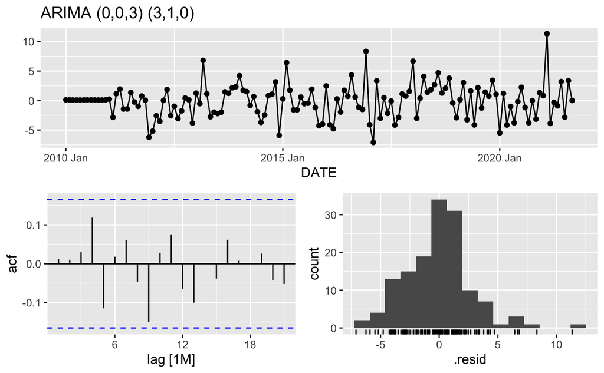

```r
#residual spread

models %>% select(m1) %>% gg_tsresiduals() + labs(title = "ARIMA (0,0,3) (3,1,0)", y="")
```

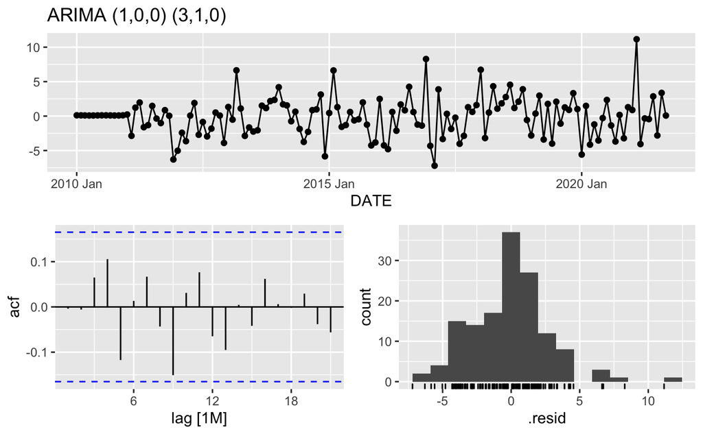

```r
models %>% select(m2) %>% gg_tsresiduals() + labs(title = "ARIMA (1,0,0) (3,1,0)", y="")
```

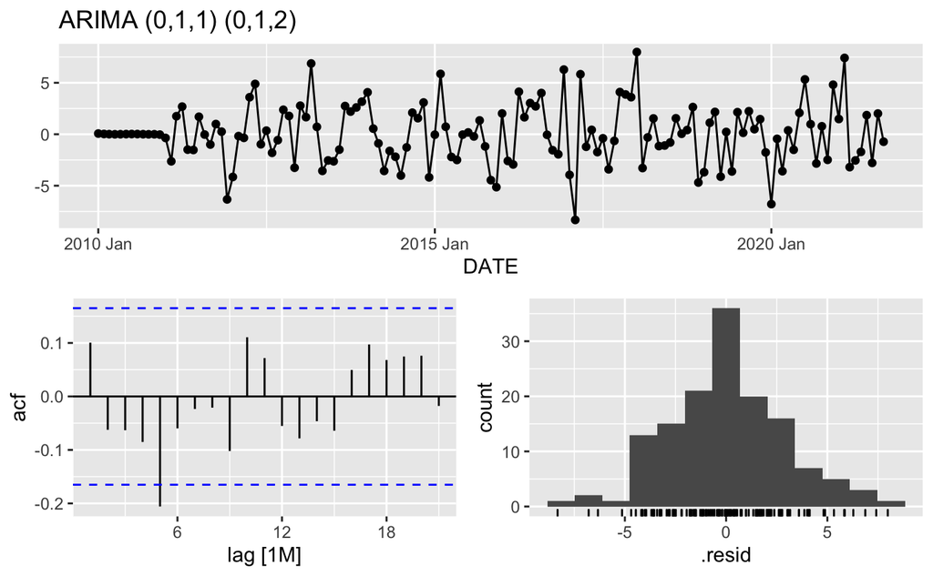

```r
models %>% select(m3) %>% gg_tsresiduals() + labs(title = "ARIMA (0,1,1) (0,1,2)", y="")
```

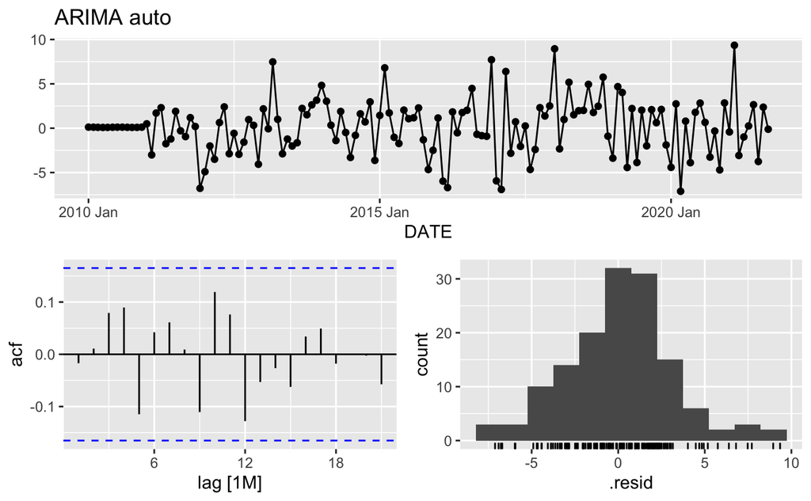

```r
models %>% select(ARIMA_auto) %>% gg_tsresiduals() + labs(title = "ARIMA auto", y="")
```

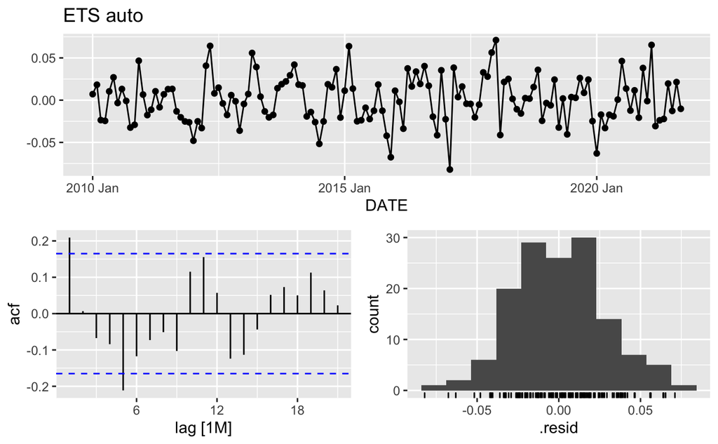

```r
models %>% select(ETS_auto) %>% gg_tsresiduals() + labs(title = "ETS auto", y="")
```

**ARIMA(0,1,1)(0,1,2) model has small but one significant spike at lag 5 but remaining are consistent with white noise. Moreover, auto ETS models has spikes at lag 1 and 5. Hence, we conducted the Ljung Box test to have more clarity.**

Null hypothesis for Ljung-Box method is that the residuals are uncorrelated and random. Hence, we need to have large p-values so that the null hypothesis can not be rejected. All models except the auto ETS models have high p-values, hence those residuals are consistent with white noise.

**ARIMA(0,1,1)(0,1,2) model has p-value which is relatively lower (~22%) when compared to other ARIMA models but is still large enough for the null hypothesis to not be rejected. Other ARIMA models have fairly large p-values.**

**Auto ETS model has p-value lower than 5%, hence the forecast from this model may not be valid.**

4. For the set of five models selected (automatically and/or manually) examine the in-sample accuracy metrics. Based on a holistic analysis of the information criteria select the best two ARIMA models and the ETS model. Report the model name/order and their parameter values.

```r
# accuracy metrics
models %>% accuracy()
```

| .model | .type | ME | RMSE | MAE | MPE | MAPE | MASE | RMSSE | ACF1 |
| --- | --- | --- | --- | --- | --- | --- | --- | --- | --- |
| m1 | Training | -0.10461883 | 2.850554 | 2.118327 | -0.1617081080 | 2.063020 | 0.6446948 | 0.6693863 | 0.011899177 |
| m2 | Training | -0.10342595 | 2.851406 | 2.126164 | -0.1602965374 | 2.071254 | 0.6470799 | 0.6695864 | -0.003872864 |
| m3 | Training | 0.03635241 | 2.850872 | 2.170035 | -0.0008858821 | 2.130015 | 0.6604316 | 0.6694608 | 0.100573225 |
| ARIMA_auto | Training | 0.15003904 | 3.101431 | 2.368615 | 0.0895230856 | 2.310460 | 0.7208676 | 0.7282988 | -0.017019190 |
| ETS_auto | Training | 0.03559121 | 2.884700 | 2.289642 | -0.0236680241 | 2.246754 | 0.6968331 | 0.6774046 | 0.202330995 |

```r
# reporting model details and parameters

models %>% select(m1) %>% report()
```

```
Series: ELEC
Model: ARIMA(0,0,3)(3,1,0)[12] w/ drift

Coefficients:
         ma1     ma2     ma3     sar1     sar2     sar3  constant
      0.2939  0.0818  0.0659  -0.5171  -0.6113  -0.3727    0.7636
s.e.  0.0940  0.0884  0.1053   0.0908   0.0875   0.0903    0.4272

sigma^2 estimated as 9.391:  log likelihood=-330.19
AIC=676.38   AICc=677.58   BIC=699.26
```

```r
models %>% select(m2) %>% report()
```

```
Series: ELEC
Model: ARIMA(1,0,0)(3,1,0)[12] w/ drift

Coefficients:
         ar1     sar1     sar2     sar3  constant
      0.3158  -0.5234  -0.6094  -0.3717    0.5223
s.e.  0.0904   0.0889   0.0863   0.0902    0.2962

sigma^2 estimated as 9.245:  log likelihood=-330.17
AIC=672.33   AICc=673.02   BIC=689.49
```

```r
models %>% select(ARIMA_auto) %>% report()
```

```
Series: ELEC
Model: ARIMA(1,0,0)(2,1,0)[12]

Coefficients:
         ar1     sar1     sar2
      0.3757  -0.3375  -0.4386
s.e.  0.0877   0.0834   0.0870

sigma^2 estimated as 10.76:  log likelihood=-337.76
AIC=683.53   AICc=683.85   BIC=694.97
```

```r
models %>% select(ETS_auto) %>% report()
```

```
Series: ELEC
Model: ETS(M,N,A)
  Smoothing parameters:
    alpha = 0.2924178
    gamma = 0.0001000089

  Initial states:
     l[0]     s[0]     s[-1]     s[-2]     s[-3]    s[-4]    s[-5]      s[-6]     s[-7]
 101.0318 7.817185 -6.612555 -11.00125 -2.759789 8.873747 10.47588 -0.3751617 -11.78396
     s[-8]     s[-9]   s[-10]   s[-11]
 -13.88839 -2.460821 6.012828 15.70228

  sigma^2:  9e-04

     AIC     AICc      BIC
1019.152 1022.992 1063.383
```

For model cross-validation purposes stretch the DR data as follows:

```r
D.CV <- DR %>%
  filter(DATE >= yearmonth("2010 Jan")) %>%
  stretch_tsibble(.init = 36, .step = 1)
```

5. Fit cross-validation models for each of the time sub-series in the stretched data for each of the four model types selected in (4). In the case(s) where the models were automatically selected, do NOT run the automatic selection under cross validation, instead enter manually the model order/type when you call the ARIMA()/ETS() function.

```r
# fitting cross-validation models

CV_m <- D.CV %>%
    model(
    m1 = ARIMA(ELEC ~ pdq(0,0,3) + PDQ(3,1,0)),
    m2 = ARIMA(ELEC ~ pdq(1,0,0) + PDQ(3,1,0)),
    Arima_auto = ARIMA(ELEC ~ pdq(1,0,0)+ PDQ(2,1,0)),
    ETS_auto = ETS(ELEC ~ error("M") + trend("N") + season("A"))
    )

CV_m %>% report()
```

| .id | .model | sigma2 | log_lik | AIC | AICc | BIC | MSE | AMSE | MAE | ar_roots | ma_roots |
| --- | --- | --- | --- | --- | --- | --- | --- | --- | --- | --- | --- |
| 1 | ETS_auto | 6.699504e-04 | -89.92369 | 209.8474 | 233.8474 | 233.6002 | 4.142725 | 4.675775 | 0.01636943 |  |  |
| 2 | ETS_auto | 6.546694e-04 | -92.94483 | 215.8897 | 238.7468 | 240.0534 | 4.135012 | 4.646309 | 0.01650131 |  |  |
| 3 | ETS_auto | 6.141459e-04 | -95.06993 | 220.1399 | 241.9580 | 244.7037 | 3.948153 | 4.453481 | 0.01594081 |  |  |
| 4 | ETS_auto | 7.806944e-04 | -102.94499 | 235.8900 | 256.7595 | 260.8434 | 4.857860 | 5.828482 | 0.01767595 |  |  |
| 5 | ETS_auto | 7.598227e-04 | -105.66874 | 241.3375 | 261.3375 | 266.6707 | 4.819414 | 5.849144 | 0.01774749 |  |  |
| 6 | ETS_auto | 7.507724e-04 | -108.77399 | 247.5480 | 266.7480 | 273.2516 | 4.763350 | 5.826695 | 0.01755444 |  |  |
| 7 | ETS_auto | 7.394048e-04 | -111.92169 | 253.8434 | 272.3049 | 279.9084 | 4.859600 | 5.498035 | 0.01751884 |  |  |
| 8 | ETS_auto | 7.389552e-04 | -115.43703 | 260.8741 | 278.6518 | 287.2921 | 4.912252 | 5.751834 | 0.01787372 |  |  |
| 9 | ETS_auto | 7.359564e-04 | -118.78261 | 267.5652 | 284.7081 | 294.3281 | 4.928560 | 7.288640 | 0.01795444 |  |  |
| 10 | ETS_auto | 7.138842e-04 | -121.59630 | 273.1926 | 289.7443 | 300.2925 | 4.948770 | 5.508067 | 0.01818809 |  |  |

[output cut: 234 more lines]

6. Prepare a 24-month ahead forecast foe each of the models fitted in (5) and prepare a plot of MAPE vs months-ahead. Based on the dynamic behavior of cross-validation MAPE discuss which model(s) should be kept/discarded.

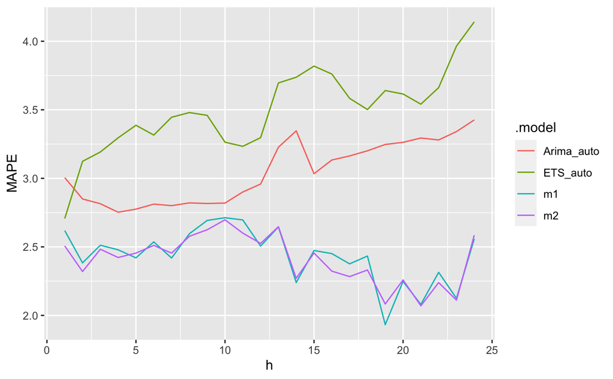

```r
#24 month forecast
CV_m %>%
  forecast(h = 24) %>%
  group_by(.id, .model) %>%
  mutate(h = row_number()) %>%
  ungroup() -> CV_f

#MAPE vs months-ahead
CV_f %>%
  accuracy(DR, by = c("h", ".model")) %>%
  ggplot(aes(x = h, y = MAPE, color = .model)) +
  geom_line()
```

7. Examine the cross-validation residuals of the models you selected in (6), and based on their correlation (model vs. model) discuss if it is advisable to prepare an ensemble forecast averaging the forecasts of two or more models.

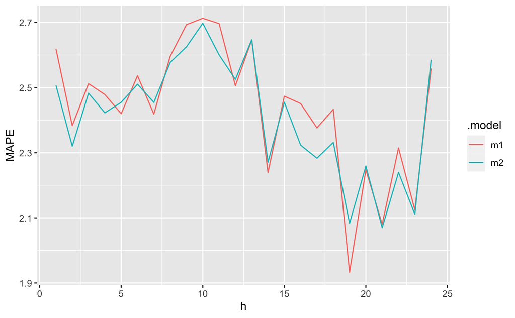

```r
# correlation between models

CV_f %>% filter(.model %in% c('m1','m2')) %>%
  accuracy(DR, by = c("h", ".model")) %>%
  ggplot(aes(x = h, y = MAPE, color = .model)) +
  geom_line()
```

8. The index is very useful for energy planning purpose as most of the variability and seasonality is produced by combined cycle natural gas plants and single cycle peaker plants that also run on natural gas (i.e., nuclear and coal generation is fixed and relatively constant). For this purpose it is of interest to know what is the production index level that will not be superated with a probability (service-level) of 95%. For the best model in (6) plot the 24-month ahead forecast and plot the forecast and the corresponding confidence interval to help you address the service level question. Report numerically the month-by-month the index forecasts that meet the desired 95% service level.

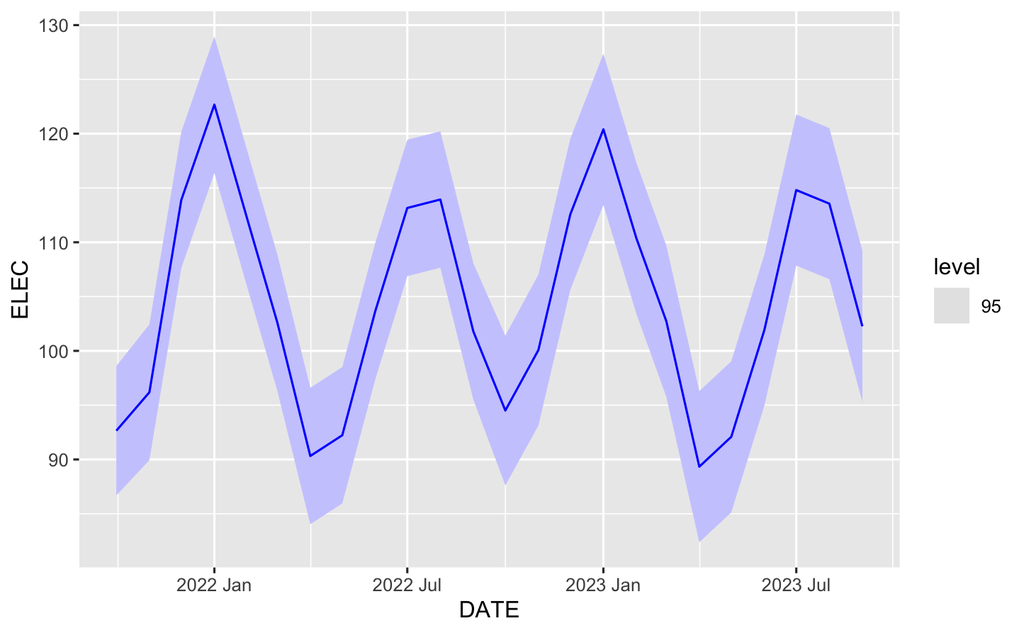

```r
#plotting the 24 month forecast for the best model in 6 i.e. m2: ARIMA (1,0,0) (3,1,0)
models %>%
  select(m2) %>%
  forecast(h = 24) %>%
  autoplot(level = c(95))
```

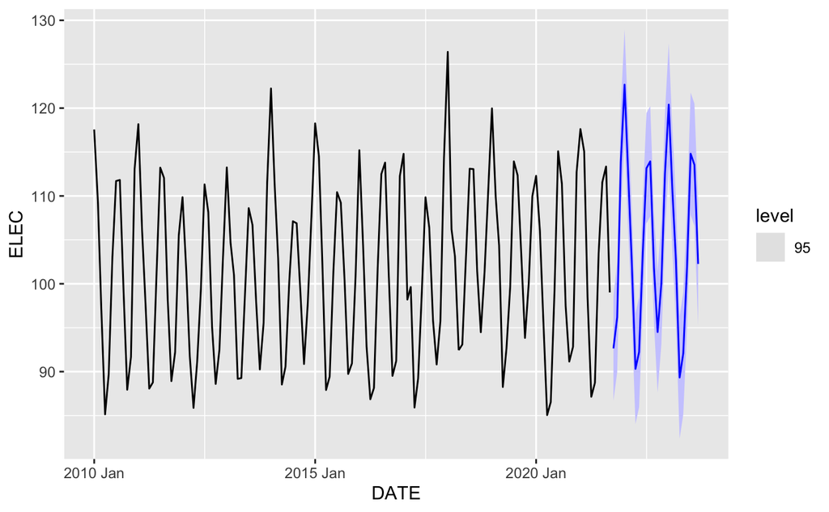

```r
#plotting the entire trend along with forecast
models %>%
  select(m2) %>%
  forecast(h = 24) %>%
  autoplot(DR, level = c(95))
```

```r
#reporting the numerical values corresponding to 95% confidence interval
models %>%
  select(m2) %>%
  forecast(h = 24) %>%
  hilo(level = c(90)) %>%
  unpack_hilo("90%") %>%
  select (DATE, .mean, "90%_lower", "90%_upper")
```

| DATE | .mean | 90%_lower | 90%_upper |
| --- | --- | --- | --- |
| 2021 Oct | 92.64573 | 87.64440 | 97.64705 |
| 2021 Nov | 96.18265 | 90.93788 | 101.42742 |
| 2021 Dec | 113.90536 | 108.63694 | 119.17379 |
| 2022 Jan | 122.67437 | 117.40359 | 127.94515 |
| 2022 Feb | 112.08718 | 106.81616 | 117.35819 |
| 2022 Mar | 102.62543 | 97.35439 | 107.89646 |
| 2022 Apr | 90.31609 | 85.04505 | 95.58713 |
| 2022 May | 92.22689 | 86.95585 | 97.49793 |
| 2022 Jun | 103.67074 | 98.39970 | 108.94178 |
| 2022 Jul | 113.16032 | 107.88928 | 118.43136 |

[output cut: 14 more lines]